# Machine Learning Project

Kobra

08/11/2019

Outline:

One thing that people regularly do is quantify how much of a particular activity they do, but they rarely quantify how well they do it. In this project, our goal is to use data from accelerometers on the belt, forearm, arm, and dumbell of 6 participants and predict the quality of the activities. In this dataset, quality is described with 5 different levels: A,B,C,D and E under variable ‘Classe’.

# Loading data and required libraries

Downloading training data:

```r
URL1 <- "https://d396qusza40orc.cloudfront.net/predmachlearn/pml-training.csv"
download.file(URL1, destfile = "./training.csv", mode="wb")
```

```r
data <- read.csv("./training.csv")
```

Downloading data for final evaluation:

```r
URL2 <- "https://d396qusza40orc.cloudfront.net/predmachlearn/pml-testing.csv"

download.file (URL2, destfile = "./testing.csv", mode= "wb")
```

```r
Quiz <- read.csv("./testing.csv")
```

```r
dim (data)
```

```
## [1] 19622   160
```

```r
head (data)
```

|  | X | user_name | raw_timestamp_part_1 | raw_timestamp_part_2 | cvtd_timestamp | new_window | num_window | roll_belt | pitch_belt | yaw_belt | total_accel_belt | kurtosis_roll_belt | kurtosis_picth_belt | kurtosis_yaw_belt | skewness_roll_belt | skewness_roll_belt.1 | skewness_yaw_belt | max_roll_belt | max_picth_belt | max_yaw_belt | min_roll_belt | min_pitch_belt | min_yaw_belt | amplitude_roll_belt | amplitude_pitch_belt | amplitude_yaw_belt | var_total_accel_belt | avg_roll_belt | stddev_roll_belt | … |
| --- | --- | --- | --- | --- | --- | --- | --- | --- | --- | --- | --- | --- | --- | --- | --- | --- | --- | --- | --- | --- | --- | --- | --- | --- | --- | --- | --- | --- | --- | --- |
| 1 | 1 | carlitos | 1323084231 | 788290 | 05/12/2011 11:23 | no | 11 | 1.41 | 8.07 | -94.4 | 3 |  |  |  |  |  |  | NA | NA |  | NA | NA |  | NA | NA |  | NA | NA | NA | … |
| 2 | 2 | carlitos | 1323084231 | 808298 | 05/12/2011 11:23 | no | 11 | 1.41 | 8.07 | -94.4 | 3 |  |  |  |  |  |  | NA | NA |  | NA | NA |  | NA | NA |  | NA | NA | NA | … |
| 3 | 3 | carlitos | 1323084231 | 820366 | 05/12/2011 11:23 | no | 11 | 1.42 | 8.07 | -94.4 | 3 |  |  |  |  |  |  | NA | NA |  | NA | NA |  | NA | NA |  | NA | NA | NA | … |
| 4 | 4 | carlitos | 1323084232 | 120339 | 05/12/2011 11:23 | no | 12 | 1.48 | 8.05 | -94.4 | 3 |  |  |  |  |  |  | NA | NA |  | NA | NA |  | NA | NA |  | NA | NA | NA | … |
| 5 | 5 | carlitos | 1323084232 | 196328 | 05/12/2011 11:23 | no | 12 | 1.48 | 8.07 | -94.4 | 3 |  |  |  |  |  |  | NA | NA |  | NA | NA |  | NA | NA |  | NA | NA | NA | … |
| 6 | 6 | carlitos | 1323084232 | 304277 | 05/12/2011 11:23 | no | 12 | 1.45 | 8.06 | -94.4 | 3 |  |  |  |  |  |  | NA | NA |  | NA | NA |  | NA | NA |  | NA | NA | NA | … |

```r
str (data)
```

```
## 'data.frame':    19622 obs. of  160 variables:
##  $ X                       : int  1 2 3 4 5 6 7 8 9 10 ...
##  $ user_name               : Factor w/ 6 levels "adelmo","carlitos",..: 2 2 2 2 2 2 2 2 2 2 ...
##  $ raw_timestamp_part_1    : int  1323084231 1323084231 1323084231 1323084232 1323084232 1323084232 1323084232 1323084232 1323084232 1323084232 ...
##  $ raw_timestamp_part_2    : int  788290 808298 820366 120339 196328 304277 368296 440390 484323 484434 ...
##  $ cvtd_timestamp          : Factor w/ 20 levels "02/12/2011 13:32",..: 9 9 9 9 9 9 9 9 9 9 ...
##  $ new_window              : Factor w/ 2 levels "no","yes": 1 1 1 1 1 1 1 1 1 1 ...
##  $ num_window              : int  11 11 11 12 12 12 12 12 12 12 ...
##  $ roll_belt               : num  1.41 1.41 1.42 1.48 1.48 1.45 1.42 1.42 1.43 1.45 ...
##  $ pitch_belt              : num  8.07 8.07 8.07 8.05 8.07 8.06 8.09 8.13 8.16 8.17 ...
##  $ yaw_belt                : num  -94.4 -94.4 -94.4 -94.4 -94.4 -94.4 -94.4 -94.4 -94.4 -94.4 ...
##  $ total_accel_belt        : int  3 3 3 3 3 3 3 3 3 3 ...
##  $ kurtosis_roll_belt      : Factor w/ 397 levels "","-0.016850",..: 1 1 1 1 1 1 1 1 1 1 ...
##  $ kurtosis_picth_belt     : Factor w/ 317 levels "","-0.021887",..: 1 1 1 1 1 1 1 1 1 1 ...
##  $ kurtosis_yaw_belt       : Factor w/ 2 levels "","#DIV/0!": 1 1 1 1 1 1 1 1 1 1 ...
```

[output cut: 86 more lines]

# Data Cleaning

The first 7 columns do not have any information that can be related to the quality of activities. So those columns will be removed.

```r
data <- data [, -c(1:7)]
dim(data)
```

```
## [1] 19622   153
```

Also, there are NAs in the dataset which need to be handled. I have decided to take out the variables that have more than %90 NAs. If there is any remaining, na.roughfix will be used to replace NAs with either median (numeric variables) or mode (categorical variables).

```r
ColRemove <- which(colSums(is.na(data)|data=="")>0.9*dim(data)[1])
dataClean <- data[,-ColRemove]
dim (dataClean)
```

```
## [1] 19622    53
```

Checking if there is any other variable with NAs:

```r
sum(is.na (dataClean))
```

```
## [1] 0
```

The outcome shows that there is no more NA in dataset, so we are safe to move to the next step without any more preprocessing.

# Modelling- Deviding dataset to test and training

1. Dividing the data to training and test set:

```r
set.seed(1234)
InTrain <- createDataPartition(dataClean$classe, p=0.7, list = FALSE)
train <- dataClean [InTrain, ]
test <- dataClean [-InTrain, ]
dim (train)
```

```
## [1] 13737    53
```

```r
dim (test)
```

```
## [1] 5885   53
```

## Modelling using Decision Tree

Building the model:

```r
modDecisionTree <- rpart(classe~., data= train, control = rpart.control(xval = 5))
```

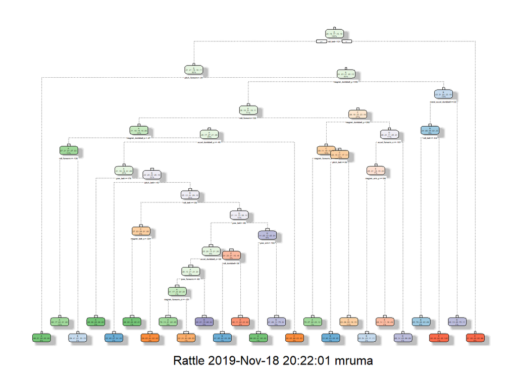

```r
fancyRpartPlot(modDecisionTree)
```

Preciting using Decision tree model:

```r
PredDT <- predict(modDecisionTree,newdata=test, type = "class")
```

Estimating the accuracy of the model:

```r
confMatCT <- confusionMatrix(test$classe,PredDT)

confMatCT$table
```

```
##           Reference
## Prediction    A    B    C    D    E
##          A 1522   58   47   25   22
##          B  167  706  109   94   63
##          C   12  100  819   67   28
##          D   49   79  148  609   79
##          E   13   96  139   52  782
```

```r
confMatCT$overall[1]
```

```
##  Accuracy
## 0.7541206
```

## Modelling using Radnom Forest

Bulding the model:

```r
modRandFor <- randomForest (classe~., data= train, rfcv=rfcv(cv.fold = 5))
```

Predicting using Random forest model:

```r
PredRF <- predict(modRandFor,newdata=test, type = "class")
```

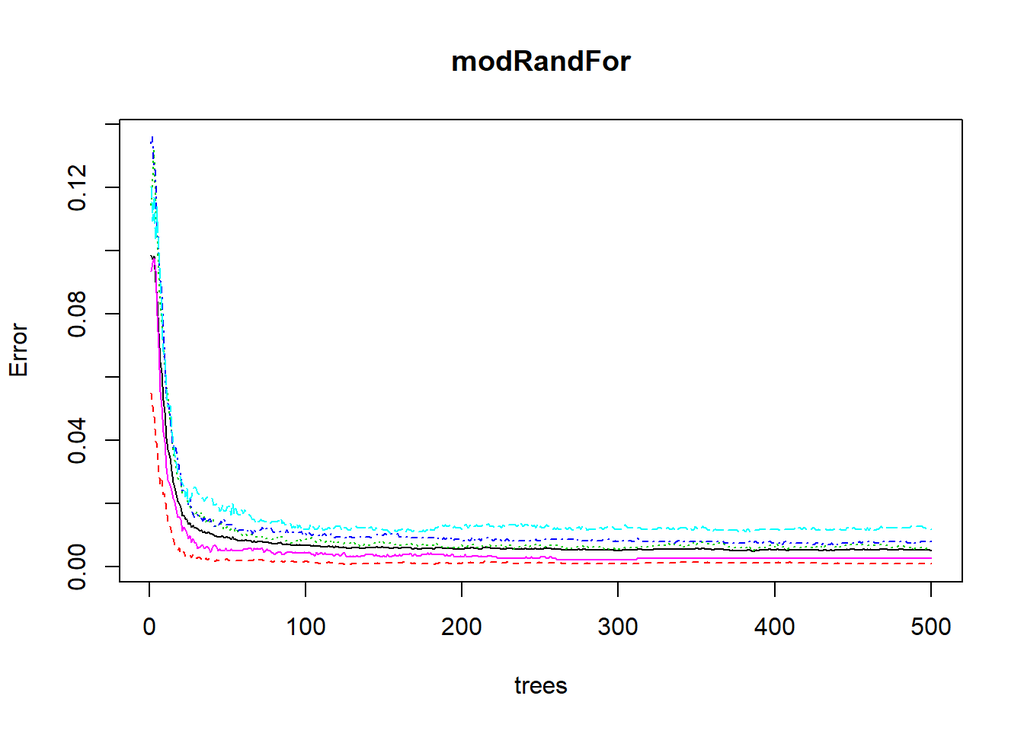

```r
plot (modRandFor)
```

Estimating the accuracy of the model:

```r
confMatRF <- confusionMatrix(test$classe,PredRF)
confMatRF$table
```

```
##           Reference
## Prediction    A    B    C    D    E
##          A 1673    1    0    0    0
##          B    2 1133    4    0    0
##          C    0   11 1014    1    0
##          D    0    0    6  957    1
##          E    0    0    0    0 1082
```

```r
confMatRF$overall[1]
```

```
## Accuracy
## 0.995582
```

# Conclusion:

Bsed on the results above, ,odelling using Random Forest algorithm gives us a very high accuracy (%99.56) which gives us enough confidence to use it for our final prediction.

# Predicting the final test data using Random Forest Model

```r
PredRF_final <- predict(modRandFor,newdata=Quiz, type = "class")
```